# I-JEPA: aprender a ver prediciendo representaciones

## I-JEPA Por qué Yann LeCun está tan enojado con los LLMs

Proyecto final

Lucca  
Frachelle

DLvis  
UDELAR - FING · 26/11/2026

## Intro

[figure not shown]

Yann LeCun, «World Models: Enabling the next AI revolution», ciclo Frontiers of Embodied AI, ETH Zürich, 2026.

## Intro

Un adolescente aprende a manejar en unas 20 horas (a mí me llevó bastante más).

Un sistema automático necesita enormes cantidades de datos etiquetados o de ensayos.

La hipótesis de LeCun La diferencia es el conocimiento previo de cómo funciona el mundo, y casi todo se adquiere observando, sin etiquetas.

## La idea

LeCun (2022), *A Path Towards Autonomous Machine Intelligence*

## Una arquitectura para un agente que predice

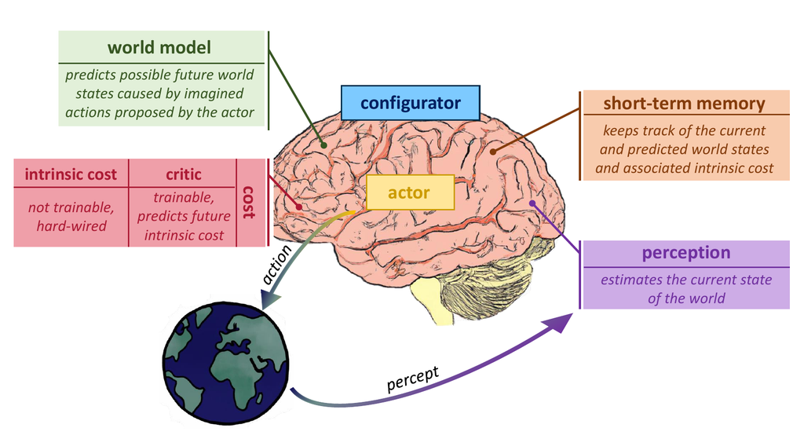

Los módulos de la arquitectura de LeCun (2022). Figura de Dawid y LeCun (2023), notas de Les Houches.

## El modelo del mundo

- Trabaja sobre un estado abstracto $s_t$, no sobre la observación cruda.
- Predice el próximo estado dada una acción:
  $$s_{t+1} = \text{Pred}(s_t,\ a_t,\ z_t)$$
- $z_t$ es una variable latente: cubre lo que no se puede saber y permite varios desenlaces.
- Planificar es buscar la secuencia de acciones que minimiza un costo sobre lo predicho.

El problema de aprendizaje Antes de planificar hay que aprender, sin etiquetas, un encoder que produzca $s$ y un predictor que funcione en ese espacio.

Dónde entra I-JEPA Resuelve sólo esa pieza, en imágenes estáticas: sin tiempo ni acciones, y con una $z$ que sólo indica qué posición predecir, no una latente que admita varios desenlaces.

## Latentes y yo, mejores amigos

**predecir el dato**

- Predecir los píxeles que faltan (MAE).
- Si lo que falta es incierto, el error cuadrático lleva a predecir el promedio: una imagen borrosa.
- El objetivo es fijo: no colapsa mientras $z$ lleve poca información. Pero lo aprendido suele ser de menor nivel semántico.

**predecir una representación**

- Codificar lo que falta con un encoder.
- Predecir esa representación.
- El encoder puede descartar el detalle de píxel innecesario.

La tesis de LeCun Un modelo del mundo tiene que predecir en un espacio de representaciones, porque buena parte de los detalles del mundo son impredecibles e irrelevantes.

## Tres maneras de armar el problema

[interactive chart not shown]

Redibujado de la figura 2 de Assran et al. (2023). D marca dónde se mide la distancia.

## El colapso

[interactive chart not shown]

## Evitar el colapso

La energía $F(x, y)$ (en JEPA, la distancia $D(\hat s_y, s_y)$) tiene que quedar baja sobre los datos y alta en el resto. LeCun distingue dos maneras; I-JEPA usa una tercera.

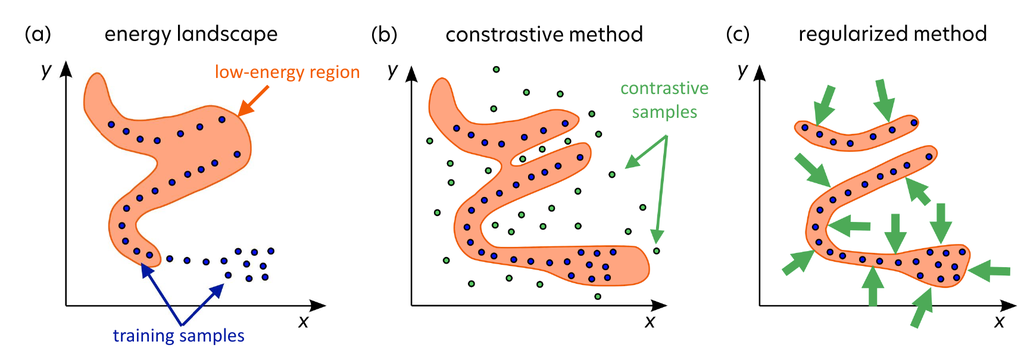

Dawid y LeCun (2023), adaptada de LeCun (2022).

## I-JEPA

Assran, Duval, Misra, Bojanowski, Vincent, Rabbat, LeCun y Ballas · CVPR 2023

## I-JEPA dibujito

[interactive chart not shown]

## Paso 1: De la imagen a los tokens

[interactive chart not shown]

Como en cualquier ViT. Cada token lleva su posición, así que el encoder de contexto puede recibir sólo un subconjunto.

## Paso 2: El enmascarado multi-bloque

[interactive chart not shown]

El objetivo no es el complemento del contexto. Lo gris no es ni uno ni otro: sólo lo ve el encoder objetivo.

## Paso 3: El encoder de contexto

[interactive chart not shown]

Procesa sólo los tokens de contexto; los objetivos nunca entran por esta rama.

## Paso 4: El encoder objetivo

[interactive chart not shown]

Procesa la imagen entera y recorta los bloques a la salida: cada \(s_y\) ya incorpora el resto de la imagen.

## Paso 5: El predictor

[interactive chart not shown]

Angosto a propósito: con ancho 1024 en vez de 384, el fine-tuning con 1 % de etiquetas baja de 70,7 a 68,4.

## Paso 6: La pérdida

[interactive chart not shown]

Paper: $\frac{1}{M}\sum_{i}\sum_{j\in B_i}\lVert \hat s_{y_j} - s_{y_j}\rVert_2^2$ ($M$ bloques; $B_i$, los parches del bloque $i$: suma sobre parches, promedio sobre bloques). Código, como en la animación: smooth L1 promediada sobre todo, contra objetivos con layer norm.

## Paso 7: La actualización por EMA

[interactive chart not shown]

Junto con el stop-gradient, esta asimetría es lo que evita el colapso en I-JEPA.

## Por qué no colapsa

[interactive chart not shown]

## Una pasada completa

[interactive chart not shown]

## Después de entrenar: la evaluación

[interactive chart not shown]

## Resultados

[interactive chart not shown]

Lo distintivo es el costo: un ViT-H/14 en menos de 72 h con 16 A100; una sola vista frente a iBOT, ~5× menos iteraciones que MAE. El 81,1 es a 448 px; el resto, a 224.

## Qué aprende el predictor

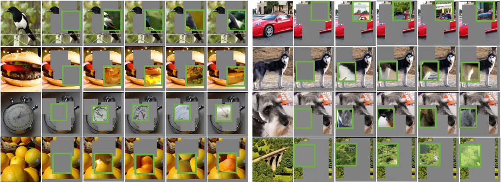

Figura 6 de Assran et al. (2023). Original, contexto visible y muestras de un decoder generativo (RCDM, entrenado aparte y sólo para visualizar) que lleva a píxeles la salida del predictor en el recuadro verde.

- Lo que se repite entre muestras es lo que la predicción contiene: la parte del objeto y su pose (el lomo del pájaro, el techo del auto).
- Lo que varía, el detalle fino y el fondo, queda afuera. Una sola predicción por bloque: no hay $z$ latente para varios desenlaces.

## Problemas y qué fue después

- Muy sensible a la máscara, que también es diseño a mano.
- No gana en todo: iNaturalist (47,6 contra 57,3 de iBOT), conteo (86,7 contra 90,5 de MAE), fine-tuning.
- Colapso: hay resultados teóricos sobre por qué EMA y stop-gradient lo evitan (Tian et al., 2021), obtenidos en redes lineales.
- Sin tiempo, sin acciones y sin variable latente para varios desenlaces: lejos del programa de 2022.

| 2024 · V-JEPA | El mismo principio en video. |
| --- | --- |
| 2025 · V-JEPA 2 | Modelo del mundo condicionado por acciones, usado para planificar con un brazo robótico. |
| 2025 · LeJEPA | SIGReg: un regularizador que lleva los embeddings a una gaussiana isótropa, en lugar de EMA y stop-gradient. |
| 2026 · SPHERE-JEPA | SUSReg: la misma idea, con la distribución uniforme sobre la esfera. |

## Referencias

Assran, Mahmoud, Quentin Duval, Ishan Misra, Piotr Bojanowski, Pascal Vincent, Michael Rabbat, Yann LeCun, y Nicolas Ballas. 2023. «Self-Supervised Learning from Images with a Joint-Embedding Predictive Architecture». En *IEEE/CVF Conference on Computer Vision and Pattern Recognition (CVPR)*.

Assran, Mido, Adrien Bardes, David Fan, Quentin Garrido, Russell Howes, Mojtaba Komeili, Matthew Muckley, et al. 2025. «V-JEPA 2: Self-Supervised Video Models Enable Understanding, Prediction and Planning».

Baevski, Alexei, Wei-Ning Hsu, Qiantong Xu, Arun Babu, Jiatao Gu, y Michael Auli. 2022. «data2vec: A General Framework for Self-supervised Learning in Speech, Vision and Language». En *International Conference on Machine Learning (ICML)*.

Balestriero, Randall, y Yann LeCun. 2025. «LeJEPA: Provable and Scalable Self-Supervised Learning Without the Heuristics».

Bardes, Adrien, Quentin Garrido, Jean Ponce, Xinlei Chen, Michael Rabbat, Yann LeCun, Mahmoud Assran, y Nicolas Ballas. 2024. «Revisiting Feature Prediction for Learning Visual Representations from Video».

Bardes, Adrien, Jean Ponce, y Yann LeCun. 2022. «VICReg: Variance-Invariance-Covariance Regularization for Self-Supervised Learning». En *International Conference on Learning Representations (ICLR)*.

Caron, Mathilde, Hugo Touvron, Ishan Misra, Hervé Jégou, Julien Mairal, Piotr Bojanowski, y Armand Joulin. 2021. «Emerging Properties in Self-Supervised Vision Transformers». En *IEEE/CVF International Conference on Computer Vision (ICCV)*.

Dawid, Anna, y Yann LeCun. 2023. «Introduction to Latent Variable Energy-Based Models: A Path Towards Autonomous Machine Intelligence». https://arxiv.org/abs/2306.02572.

Dosovitskiy, Alexey, Lucas Beyer, Alexander Kolesnikov, Dirk Weissenborn, Xiaohua Zhai, Thomas Unterthiner, Mostafa Dehghani, et al. 2021. «An Image is Worth 16x16 Words: Transformers for Image Recognition at Scale». En *International Conference on Learning Representations (ICLR)*.

Garrido, Quentin, Mahmoud Assran, Nicolas Ballas, Adrien Bardes, Laurent Najman, y Yann LeCun. 2024. «Learning and Leveraging World Models in Visual Representation Learning».

Grill, Jean-Bastien, Florian Strub, Florent Altché, Corentin Tallec, Pierre H. Richemond, Elena Buchatskaya, Carl Doersch, et al. 2020. «Bootstrap Your Own Latent: A New Approach to Self-Supervised Learning». En *Advances in Neural Information Processing Systems (NeurIPS)*.

He, Kaiming, Xinlei Chen, Saining Xie, Yanghao Li, Piotr Dollár, y Ross Girshick. 2022. «Masked Autoencoders Are Scalable Vision Learners». En *IEEE/CVF Conference on Computer Vision and Pattern Recognition (CVPR)*.

LeCun, Yann. 2022. «A Path Towards Autonomous Machine Intelligence». https://openreview.net/forum?id=BZ5a1r-kVsf.

Nicollier, Léo, Max Dunitz, Marc Pic, Pablo Musé, Enric Meinhardt-Llopis, y Gabriele Facciolo. 2026. «SPHERE-JEPA: Spherical Prediction with Homogeneous Embeddings».

Tian, Yuandong, Xinlei Chen, y Surya Ganguli. 2021. «Understanding Self-Supervised Learning Dynamics without Contrastive Pairs». En *International Conference on Machine Learning (ICML)*.

**Declaración de uso de IA:** Se usó Claude Opus 5.5 para programar las animaciones, autocompletar algunas fórmulas y otras tareas de apoyo. Los experimentos y su código también los hizo en su mayoría Claude. Todo el proceso tuvo intervención humana en todas sus partes.

## Gracias por su atención

¿Preguntas?

## Apéndice: experimentos de juguete

Por si sobra tiempo

## La pregunta

- I-JEPA evita el colapso con asimetría: EMA y stop-gradient, con resultados teóricos en redes lineales (Tian et al., 2021).
- **LeJEPA** (Balestriero y LeCun, 2025) y SPHERE-JEPA (Nicollier y otros, entre ellos Musé, 2026) usan un regularizador que fija la forma de la distribución de los embeddings.
- Ambos se probaron con vistas aumentadas, no con máscaras; y aun ahí, sin EMA pierden 8 a 12 puntos.
- **¿Reemplazan al EMA dentro de I-JEPA?**

|  | con EMA | sin EMA |
| --- | --- | --- |
| sin regularizador | **C1** I-JEPA | **C2** control |
| SIGReg (gaussiana) | **C3** | **C4** |
| SUSReg (esfera) | **C5** | **C6** |

ViT-Tiny/16 · ImageNet-100 · 224 px · 100 épocas · 3 semillas (C2: 1) · ~40 h de GPU la grilla. Tubería validada reproduciendo SPHERE-JEPA con su código: 72,8 contra 71,9 publicado.

## Dos regularizadores, por arriba

[interactive chart not shown]

Actúan sobre una cabeza MLP sobre el contexto: \(L = L_\text{pred} + \lambda\,L_\text{reg}\), con \(\lambda = 0{,}05\) barrido sin EMA.

## Resultados de la grilla

[interactive chart not shown]

## Qué pasó con el colapso

[interactive chart not shown]

Con regularizador, el rango sube rápido pero se estanca en 57–69; C1 llega a ~102 y C2 se queda en ~28.

Límites: escala chica, λ elegido sin EMA y un control que colapsó sólo en parte.